# CH3_Exercises

Ben Jones

12 February 2019

```r
library(rethinking)
p_grid <- seq(from = 0, to = 1, length.out = 1000)
prior <- rep(1,1000)
likelihood <- dbinom(6, size = 9, prob = p_grid)
posterior <- likelihood * prior
posterior <- posterior/sum(posterior)
set.seed (100)
samples <- sample(p_grid, prob = posterior, size = 1e4, replace = TRUE)
```

*3E1:*

```r
sum(samples<0.2)/length(samples)
```

```
## [1] 5e-04
```

*3E2:*

```r
sum(samples > 0.8)/length(samples)
```

```
## [1] 0.1117
```

*3E3:*

```r
sum(samples > 0.2 & samples< 0.8)/length(samples)
```

```
## [1] 0.8878
```

*3E4:*

```r
quantile(samples, probs = 0.2)
```

```
##       20%
## 0.5195195
```

*3E5:*

```r
quantile(samples,0.8)
```

```
##       80%
## 0.7567568
```

*3E6:*

```r
HPDI(samples,0.66)
```

```
##     |0.66     0.66|
## 0.5205205 0.7847848
```

*3E7:*

```r
PI(samples, 0.66)
```

```
##       17%       83%
## 0.5005005 0.7687688
```

```r
#or
quantile(samples, c((1-0.66)/2, 1-(1-0.66)/2))
```

```
##       17%       83%
## 0.5005005 0.7687688
```

*3M1:*

```r
p_grid <- seq(from = 0, to = 1, length.out = 1000)
prior = rep(1,1000)
likelihood <- dbinom(8, size = 15, prob = p_grid)
posterior <- likelihood * prior
posterior <- posterior/sum(posterior)
```

*3M2:*

```r
samples <- sample(p_grid, prob = posterior, size = 1e4, replace = T)
HPDI(samples, prob = 0.9)
```

```
##      |0.9      0.9|
## 0.3383383 0.7317317
```

*3M3:*

```r
dummy <- rbinom(1e5, size = 15, prob = samples)
sum(dummy == 8)/length(dummy)
```

```
## [1] 0.14494
```

*3M4:*

```r
posterior.new <- rbinom(1e5, size = 9, prob = samples)
sum(posterior.new == 6)/length(posterior.new)
```

```
## [1] 0.17613
```

*3M5:* 1)

```r
p_grid <- seq(from = 0, to = 1, length.out = 1000)
prior = ifelse(p_grid < 0.5, 0, 1)
likelihood <- dbinom(8, size = 15, prob = p_grid)
posterior2 <- likelihood * prior
posterior2 <- posterior2/sum(posterior2)
```

```r
samples2 <- sample(p_grid, prob = posterior2, size = 1e4, replace = T)
HPDI(samples2, prob = 0.9)
```

```
##      |0.9      0.9|
## 0.5005005 0.7147147
```

```r
dummy <- rbinom(1e5, size = 15, prob = samples2)
sum(dummy == 8)/length(dummy)
```

```
## [1] 0.15643
```

```r
posterior.new <- rbinom(1e5, size = 9, prob = samples2)
sum(posterior.new == 6)/length(posterior.new)
```

```
## [1] 0.23333
```

We can compare the posterior point estimates in order to understand which approach may be preferable:

```r
median(samples)
```

```
## [1] 0.5325325
```

```r
mean(samples)
```

```
## [1] 0.5306506
```

```r
median(samples2)
```

```
## [1] 0.5945946
```

```r
mean(samples2)
```

```
## [1] 0.6075576
```

which suggest that adding prior information improves the point estimate of the true probability $p$, as expected, as both the mean and median move closer to the true value of $p=0.7$. By removing all density in $p<0.5$, more certainty can be obtained by the estimate as can be seen from the highest posterior density intervals, which are narrower with an informative prior.

*3H1:*

```r
library(rethinking)
data(homeworkch3)
birthtotal <- sum(birth1) + sum(birth2)
p_grid <- seq(from = 0, to = 1, length.out = 1000)
prior <- rep(1,1000)
likelihood = dbinom(birthtotal, size = 200, prob = p_grid)
posterior <- likelihood * prior
posterior <- posterior/sum(posterior)
p_grid[which.max(posterior)]
```

```
## [1] 0.5545546
```

*3H2:*

```r
samples <- sample(p_grid, prob = posterior, size = 1e4, replace = T )
mean(samples)
```

```
## [1] 0.5542355
```

```r
median(samples)
```

```
## [1] 0.5545546
```

```r
HPDI(samples,0.5)
```

```
##      |0.5      0.5|
## 0.5305305 0.5765766
```

```r
HPDI(samples,0.89)
```

```
##     |0.89     0.89|
## 0.4964965 0.6076076
```

```r
HPDI(samples,0.97)
```

```
##     |0.97     0.97|
## 0.4764765 0.6266266
```

*3H3:*

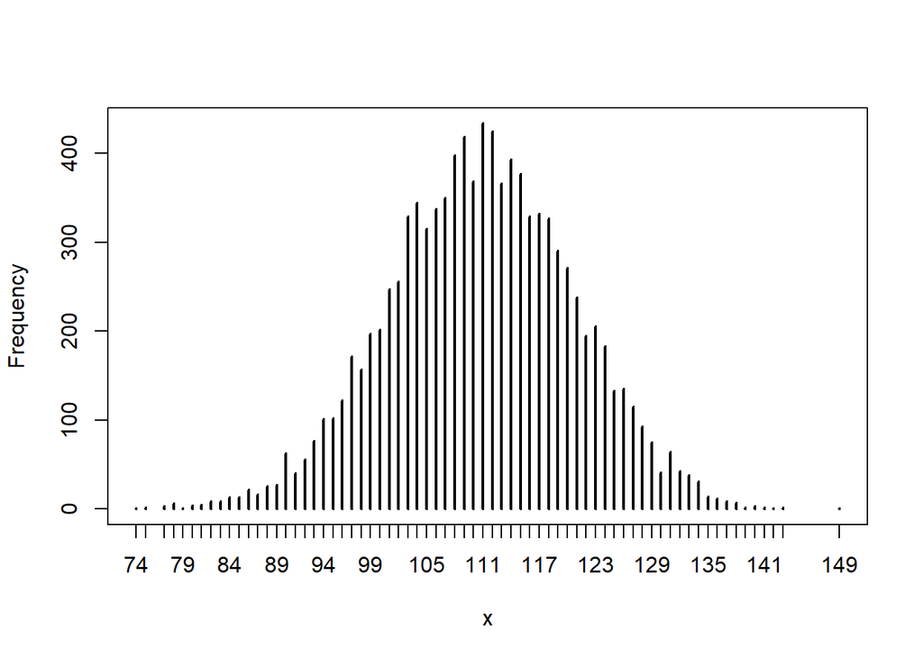

```r
sim <- rbinom(1e4, size = 200, prob = samples)
simplehist(sim)
```

```r
mean(sim)
```

```
## [1] 110.8445
```

```r
median(sim)
```

```
## [1] 111
```

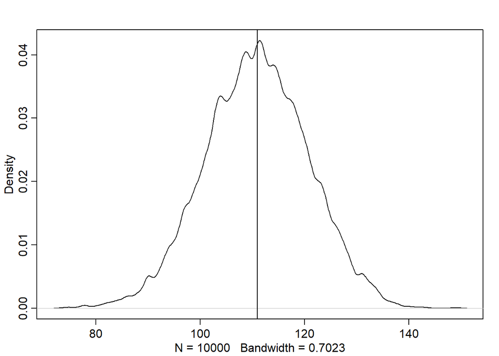

```r
dens(sim)
abline(v=111)
```

From the results above, it looks like the model fits the data well with the estimated number of male births very close to the true value of 111.

*3H4:*

```r
(nboys1 <- sum(birth1))
```

```
## [1] 51
```

```r
bsample1 <- rbinom(1e4, size = 100, prob = samples)
median(bsample1)
```

```
## [1] 55
```

```r
mean(bsample1)
```

```
## [1] 55.4464
```

Here the model slightly overestimates the number of boys fro first births

```r
(girls1 <- sum(birth1 == 0))
```

```
## [1] 49
```

```r
(boysaftergirls <- sum(birth2[birth1 == 0]))
```

```
## [1] 39
```

```r
sim2 <- rbinom(1e4, size = girls1, prob = samples)
mean(sim2)
```

```
## [1] 27.1121
```

```r
median(sim2)
```

```
## [1] 27
```

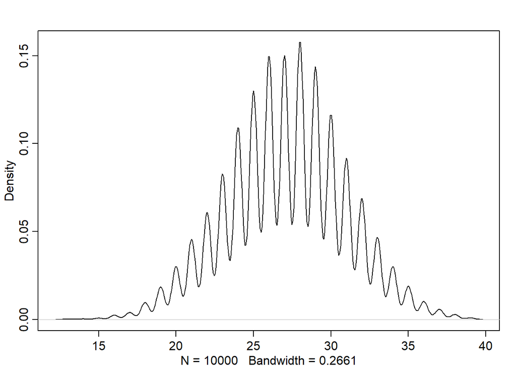

```r
dens(sim2)
```

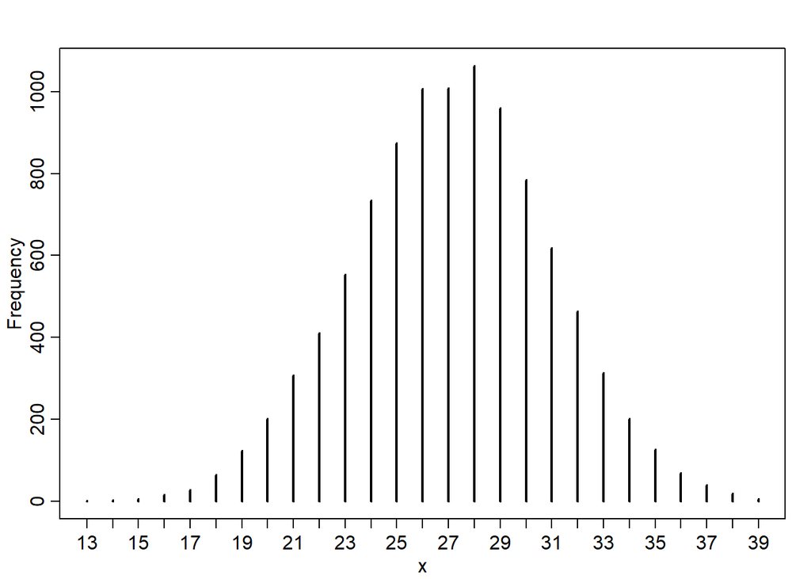

```r
simplehist(sim2)
```

The model substantially underestimates the number of boys born after the first girl, which suggets that the gender of the two births are not independent.